# Part I - (Bike Sales Dataset Exploration)

#### Categoral Variables

Customer Gender

```python
Gender_counts = df_sales["Customer_Gender"].value_counts()
print(Gender_counts)
```

```
M    58312
F    54724
Name: Customer_Gender, dtype: int64
```

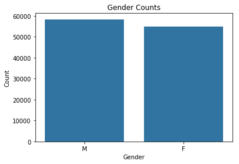

```python
Gender_counts = df_sales["Customer_Gender"].value_counts()

base_color = sns.color_palette()[0]  # Get the first color from the default color palette

sns.countplot(data=df_sales, x="Customer_Gender", color=base_color)
plt.xlabel("Gender")
plt.ylabel("Count")
plt.title("Gender Counts")

plt.show()
```

The dataset contains more Males than Females with a difference of 3,588.

Product Category

[figure not shown]

```python
# Product Category
plt.figure(figsize = [10, 5])
base_color = sb.color_palette()[0]
plt.title("Product_Category")
sb.countplot(data = df_sales, y = 'Product_Category', color = base_color,
             order = df_sales['Product_Category'].value_counts().index);
```

Lets visualise with a pie chart

```
Text(0.5,1,'product_Category')
```

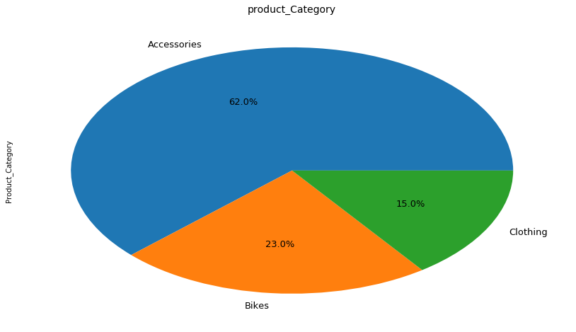

```python
df_sales["Product_Category"].value_counts().plot(kind='pie',figsize=(14,8),autopct='%1.1f%%',fontsize=13)
plt.title("product_Category",fontsize=14)
```

Age Group

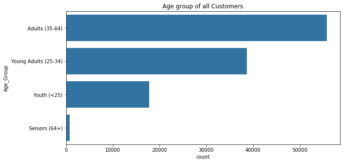

```python
#Customer Age Category

# Set the figure size
plt.figure(figsize=[10, 5])

# Define the base color for the bars
base_color = sb.color_palette()[0]

# Set the title of the plot
plt.title("Age group of all Customers")

# Create the countplot
sb.countplot(data=df_sales, y='Age_Group', color=base_color,
             order=df_sales['Age_Group'].value_counts().index)

# Display the plot
plt.show()
```

Lets see this again with donut plot

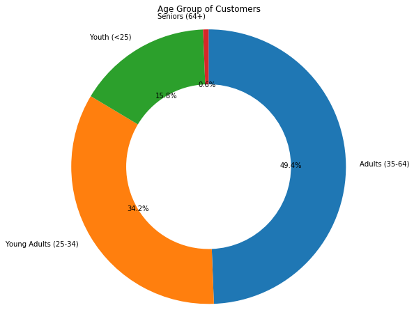

```python
# Set the figure size
plt.figure(figsize=[15, 8])

# Get the sorted counts of each age group
sorted_counts = df_sales['Age_Group'].value_counts()

# Create the pie chart
plt.pie(sorted_counts, labels=sorted_counts.index, startangle=90,
        counterclock=False, wedgeprops={'width': 0.4}, autopct='%.1f%%')

# Set the title of the plot
plt.title("Age Group of Customers")

# Set the aspect ratio to make the plot a square
plt.axis('square')

# Display the plot
plt.show()
```

Adult (35-64) happens to be bringing in more sales.

Country

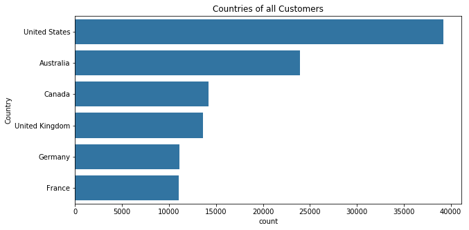

```python
#Countries of all customer
# Set the figure size
plt.figure(figsize=[10, 5])

# Define the base color for the bars
base_color = sb.color_palette()[0]

# Set the title of the plot
plt.title("Countries of all Customers")

# Create the countplot
sb.countplot(data=df_sales, y='Country', color=base_color,
             order=df_sales['Country'].value_counts().index)

# Display the plot
plt.show()
```

Most sales happens to come from the United States.

State

```python
df_sales['State'].value_counts().head(15)
```

```
California             22450
British Columbia       14116
England                13620
Washington             11264
New South Wales        10412
Victoria                6016
Oregon                  5286
Queensland              5220
Saarland                2770
Nordrhein-Westfalen     2484
Hessen                  2384
Seine (Paris)           2328
Hamburg                 1836
Seine Saint Denis       1684
Nord                    1670
Name: State, dtype: int64
```

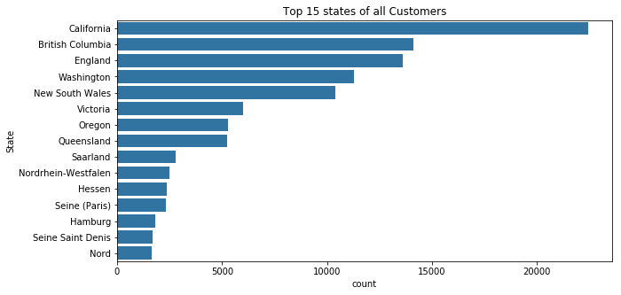

```python
# Set the figure size
plt.figure(figsize=[10, 5])

# Define the base color for the bars
base_color = sb.color_palette()[0]

# Create the countplot
sb.countplot(data=df_sales, y='State', color=base_color,
             order=df_sales['State'].value_counts().head(15).index)

# Set the title of the plot
plt.title("Top 15 states of all Customers")

# Display the plot
plt.show()
```

Califonia has most sales by States

Products

```python
df_sales['Product'].value_counts().head(15)
```

```
Water Bottle - 30 oz.      10794
Patch Kit/8 Patches        10416
Mountain Tire Tube          6816
AWC Logo Cap                4358
Sport-100 Helmet, Red       4220
Road Tire Tube              4176
Sport-100 Helmet, Black     4152
Fender Set - Mountain       4032
Sport-100 Helmet, Blue      3788
Touring Tire Tube           3702
Road Bottle Cage            2640
Mountain Bottle Cage        2444
Bike Wash - Dissolver       1804
HL Mountain Tire            1800
LL Road Tire                1686
Name: Product, dtype: int64
```

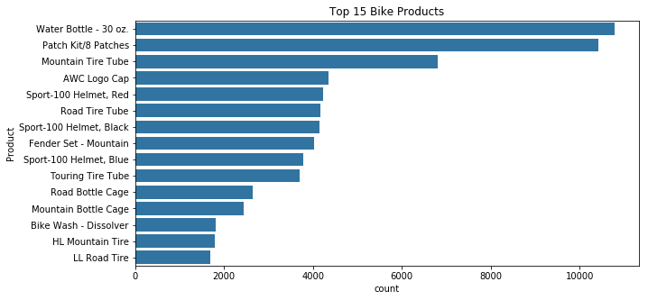

```python
# Set the figure size
plt.figure(figsize=[10, 5])

# Define the base color for the bars
base_color = sb.color_palette()[0]

# Create the countplot
sb.countplot(data=df_sales, y='Product', color=base_color,
             order=df_sales['Product'].value_counts().head(15).index)

# Set the title of the plot
plt.title("Top 15 Bike Products")

# Display the plot
plt.show()
```

Water botle top the list of sales for Bike Products

Sub Category

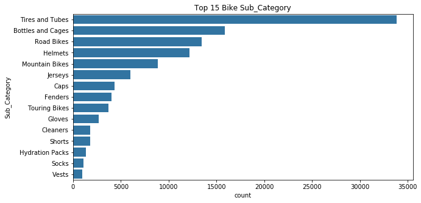

```python
# Top Bike Sub_Category
# Set the figure size
plt.figure(figsize=[10, 5])

# Define the base color for the bars
base_color = sb.color_palette()[0]

# Create the countplot
sb.countplot(data=df_sales, y='Sub_Category', color=base_color,
             order=df_sales['Sub_Category'].value_counts().head(15).index)

# Set the title of the plot
plt.title("Top 15 Bike Sub_Category")

# Display the plot
plt.show()
```

Tires and Tubes happens to be the highest sub_category

Age Group

```python
age_group_counts = df_sales['Age_Group'].value_counts()

print(age_group_counts)
```

```
Adults (35-64)          55824
Young Adults (25-34)    38654
Youth (<25)             17828
Seniors (64+)             730
Name: Age_Group, dtype: int64
```

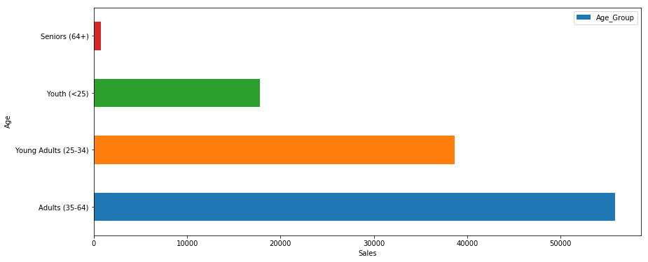

```python
# Assuming you have a DataFrame called Sales with an "Age_Group" column
age_group_counts = df_sales["Age_Group"].value_counts()

# Plotting the vertical bar chart
plt.figure(figsize=(14, 6))
age_group_counts.plot(kind='barh')  # Use kind='barh' for a vertical bar chart

# Adding labels and legends
plt.xlabel("Sales")
plt.ylabel("Age")
plt.legend()

# Displaying the plot
plt.show()
```

Adult (35-64) top the list of Age group that brough in most sales

### Discuss the distribution(s) of your variable(s) of interest. Were there any unusual points? Did you need to perform any transformations?

> From the profit plot, it was observed that it took a large range of value then I had to transform using log. The plot makes more sense after transforming it.

### Of the features you investigated, were there any unsual distribution? Did you perfrom any operations on the data to tidy, adjust, or chnage the form of the data? If so, why did you do this?

> There were no unsual distribution.

## Bivariate Exploration

Here I will be lookig at relationships between two variables

Quantitative vs Categorical

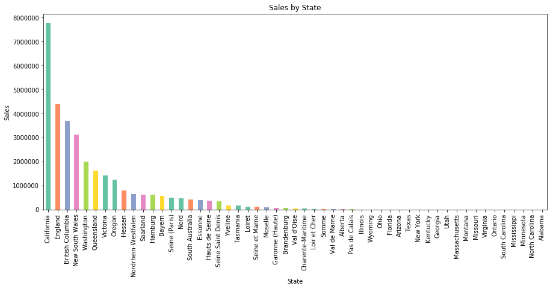

```python
# Assuming you have a DataFrame called df_sales with columns "State" and "Sales"
state_sales = df_sales.groupby('State')['Profit'].sum().sort_values(ascending=False)

# Plotting the sales by state using a bar plot
plt.figure(figsize=(15, 6))
state_sales.plot(kind='bar')

# Adding labels and title to the plot
plt.xlabel("State")
plt.ylabel("Sales")
plt.title("Sales by State")

# Displaying the plot
plt.show()
```

Revenue by Customer Gender

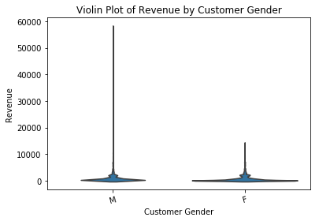

```python
# Set the base color for the plot
base_color = sb.color_palette()[0]

# Create the violin plot
sb.violinplot(data=df_sales, x='Customer_Gender', y='Revenue', color=base_color, inner=None)

# Rotate the x-axis labels for better visibility
plt.xticks(rotation=15)

# Set the x-axis label
plt.xlabel('Customer Gender')

# Set the y-axis label
plt.ylabel('Revenue')

# Set the title of the plot
plt.title('Violin Plot of Revenue by Customer Gender')

# Display the plot
plt.show()
```

Male customers brought it more revenue

Proft by Months

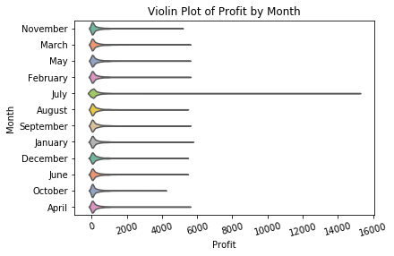

```python
# Create the violin plot
sb.violinplot(data=df_sales, y='Month', x='Profit', palette='Set2', inner=None)

# Set the x-axis label
plt.xlabel('Profit')

# Set the y-axis label
plt.ylabel('Month')

# Set the title of the plot
plt.title('Violin Plot of Profit by Month')

# Rotate the x-axis labels for better visibility
plt.xticks(rotation=15)

# Display the plot
plt.show()
```

July with highest profit made

Categorical by Categorical

Age Group by Gender, Product_category by Gender and Product Category by Age_group

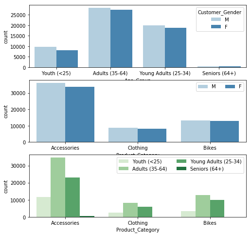

```python
# since there's only three subplots to create, using the full data should be fine.
plt.figure(figsize = [8, 8])

# subplot 1: color vs cut
plt.subplot(3, 1, 1)
sb.countplot(data = df_sales, x = 'Age_Group', hue = 'Customer_Gender', palette = 'Blues')

# subplot 2: clarity vs. cut
ax = plt.subplot(3, 1, 2)
sb.countplot(data = df_sales, x = 'Product_Category', hue = 'Customer_Gender', palette = 'Blues')
ax.legend(ncol = 2) # re-arrange legend to reduce overlapping

# subplot 3: clarity vs. color, use different color palette
ax = plt.subplot(3, 1, 3)
sb.countplot(data = df_sales, x = 'Product_Category', hue = 'Age_Group', palette = 'Greens')
ax.legend(loc = 1, ncol = 2) # re-arrange legend to remove overlapping

plt.show()
```

Quantitave by Quantitative Variables

Total Profits made according to Customer Age

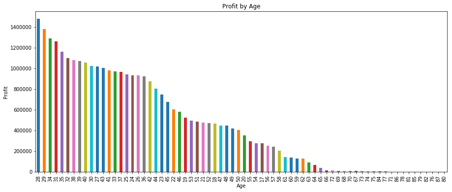

```python
# Assuming you have a DataFrame called df_sales with columns "State" and "Sales"
state_sales = df_sales.groupby('Customer_Age')['Profit'].sum().sort_values(ascending=False)

# Plotting the sales by state using a bar plot
plt.figure(figsize=(15, 6))
state_sales.plot(kind='bar')

# Adding labels and title to the plot
plt.xlabel("Age")
plt.ylabel("Profit")
plt.title("Profit by Age")

# Displaying the plot
plt.show()
```

Customers at the age of 28 years old brought in more Profit for the store

Relationship between Revenue and Profit

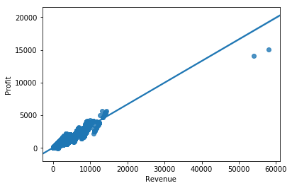

```python
sns.regplot(data= df_sales,x='Revenue', y= 'Profit')
plt.show()
```

```python
#  df_sales with "Revenue" and "Profit" columns
correlation = df_sales['Revenue'].corr(df_sales['Profit'])

print("Correlation coefficient between Revenue and Profit:", correlation)
```

```
Correlation coefficient between Revenue and Profit: 0.956571664074
```

This indicates a positive correlation. Meaning that the higer the revenue the higher the profit made

Relationship between Cost and Revenue

```python
# df_sales with "Cost" and "Revenue" columns

sns.regplot(data=df_sales, x='Cost', y='Revenue')

plt.xlabel('Cost')
plt.ylabel('Revenue')
plt.title('Scatter Plot of Revenue vs Cost')

plt.show()
```

[output not shown]

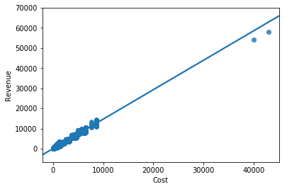

```python
#Corellation plot for Cost and Revenue
sns.regplot(data= df_sales,x='Cost', y= 'Revenue')
plt.show()
```

```python
#  df_sales with "Cost" and "Revenue" columns
correlation = df_sales['Cost'].corr(df_sales['Revenue'])

print("Correlation coefficient between Cost and Revenue:", correlation)
```

```
Correlation coefficient between Cost and Revenue: 0.988758400073
```

The above corelation result indicte clear that there is positive corelation between Cost and Revenue